# Project 1: Urban Ministries of Durham Data

Alfredo Rojas

10/07/2019

## Introduction

This project will be exploring a dataset from the Urban Ministries of Durham (UMD). UMD has provided a .TSV file with information of services provided for their clients over the past couple of decades. In this project I will be exploring two variables: the amount of food provided for clients (in pounds) and the number of clothing items provided.

My questions are:

### Q1: How has the amount of food and clothing items changed over the years?

### Q2: What is the relationship between food and clothing items provided per day and by client?

To do so, I will rely on the `tidyverse` and `dplyr` packages, as well as on `ggplot2` for visualization. To start, I will need to upload some packages before I can begin cleaning the data.

## Cleaning the data

The first thing I notice is that some of the variables contain all NAs. Let’s remove them.

Next, I want to change the date format so it is interpretable by R:

The next thing I will do is to clean up the data using pipes and common functions from the `dplyr` package. This creates a new object `UMD_food` that has new variables, such as “Pounds per person”, “Sum of Food Pounds”, “Average People who Received Food”, and “Sum of Clothes Items Given.” These are given the variable names: `lbs_per_prsn`, `food_pounds_sum`, `ppl_avg`, and `clothes_sum`, respectively.

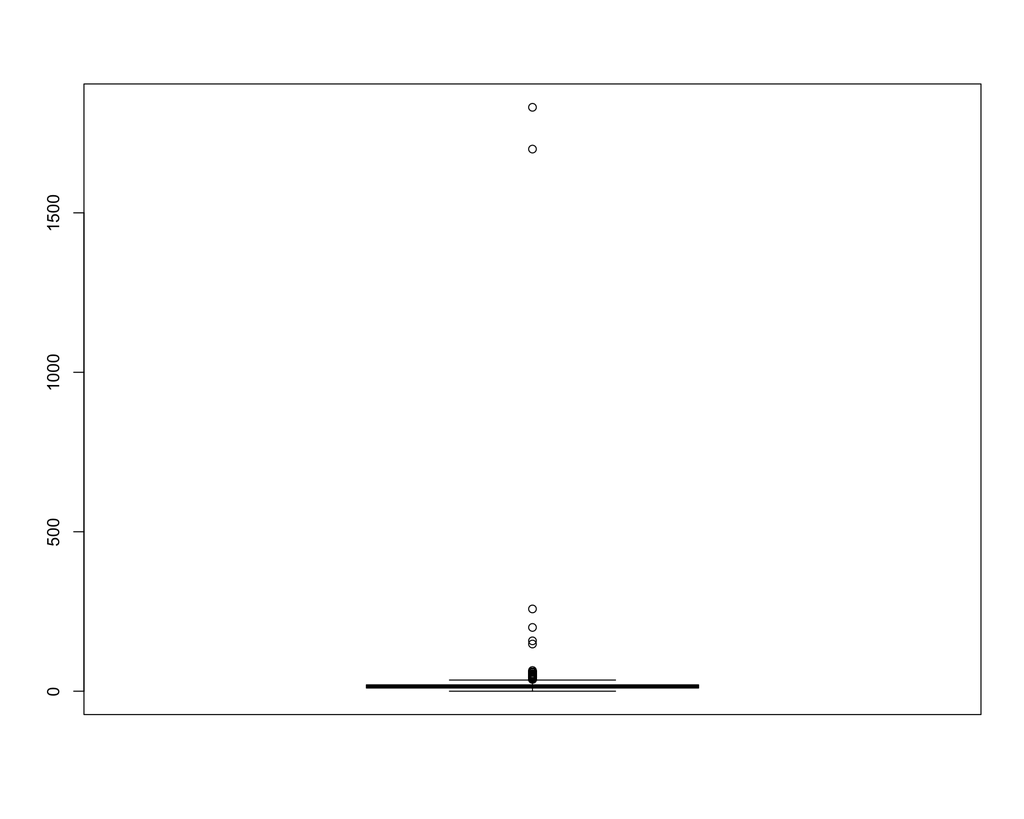

# Plotting the data

Now that I have cleaned up the data, I want to plot it. I want to look at the amount of food provided and clothing items given on a monthly basis from the year 2000 to 2019. I can do that like this:

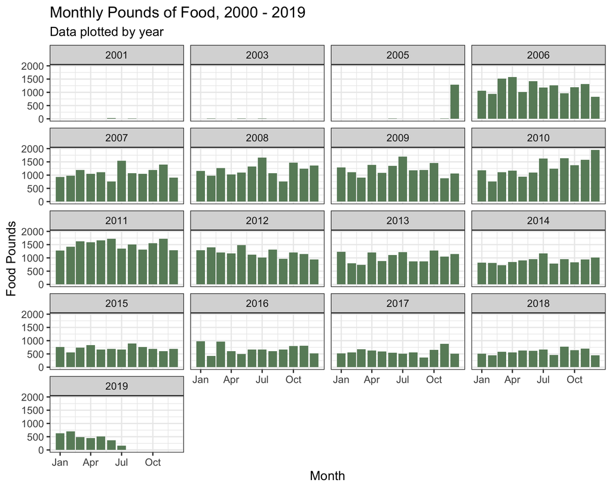

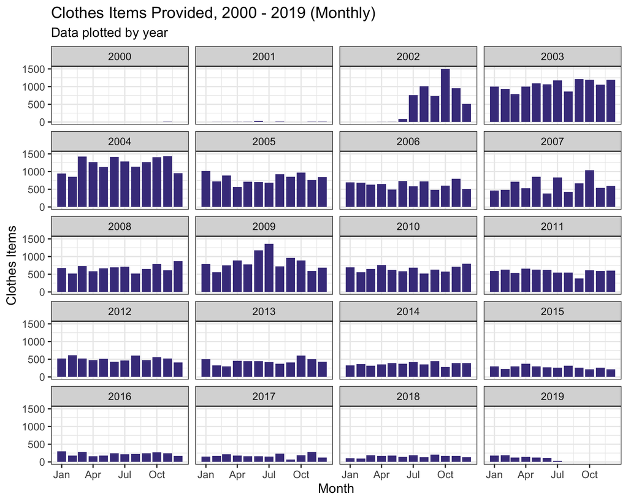

# Point Graphs

Next, I look at the relationship between food and clothing items. The first pair of graphs look at the relationship of daily observations of `Food Pounds` and `Clothing Items` by taking the sum of each variable per day. In other words, I look at the total number of food pounds and clothing items grouped by `Date`. In addition to this plot, I explore the relationship between `Clothing Items` per daily visit and the aily `Food Pounds` per person.

I can plot the graphs side by side like this using the `gridExtra` package:

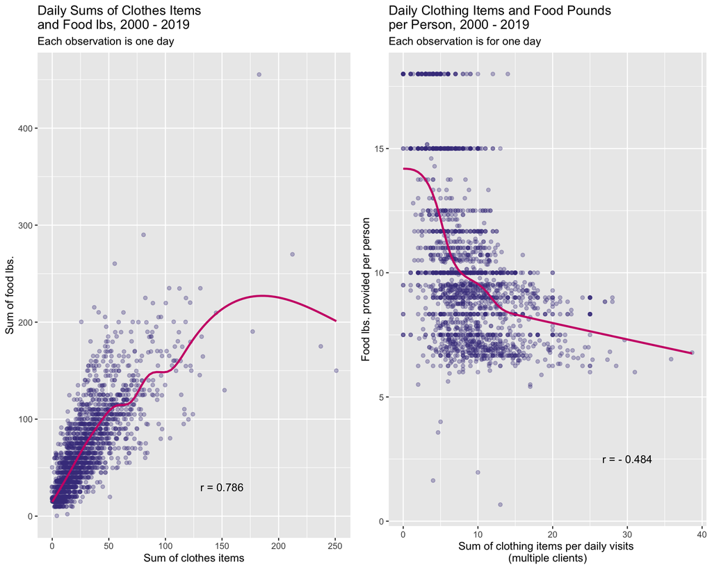

This went against my expectation since the first graph showed a positive correlation between total sum of food and clothing per day. Instead, it seems like the less clothing items handed out meant the more food was given that day. I would have assumed that daily food pounds per person would also be positively correlated with the amount of clothing items given per number of daily visits.

I want to verify whether this kind of relationship exists when we group by clients. Perhaps the opposing trend will go away if we group differently.

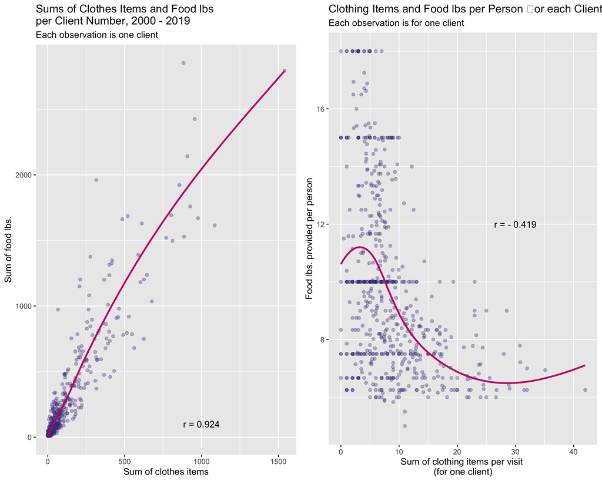

As expected, the relationship between total sums of food and clothes is highly positive when we look at each client. But, the relationship between food per person and clothing item per client is negative. So, it seems like the less clothes a client receives means they usually get more food, and vice versa.

The next thing I should do is determine whether this relationship is significant. During another iteration of this project, I can test for this.

## Conclusion

Over time, the monthly amoung of food pounds and clothing items has reduced over time. We can observe this in the yearly bar graphs that show the sum of food and clothes on a monthly basis.

On a daily basis, the sum of food pounds and clothing items are positively correlated. However, the sum of food pounds per person and the sum of clothing items given per daily visit is negative.

When looking at this relationship grouped by `Client Number`, it remains the same. We can tentatively conclude that the less clothing items someone receives, the more food they may receive per person.

We cannot conclude this without further statistical ananlyses, which can be done at a later iteration of this project.